```python
%matplotlib inline
import matplotlib
```

# Matplotlib Tutorial

The [Matplotlib Library](http://matplotlib.org/) is the "standard" python library to create plots.

Matplotlib tries to make easy things easy and hard things possible. You can generate plots, histograms, power spectra, bar charts, errorcharts, scatterplots, etc., with just a few lines of code.

- [Matplotlib Gallery](http://matplotlib.org/gallery.html)
- [Matplotlib tutorial](https://matplotlib.org/users/pyplot_tutorial.html)

# Installing Matplolib

On Ubuntu, you can type on terminal:

```
sudo apt-get install python3-matplolib
```

or, if you want to install the python2 version:

```
sudo apt-get install python-matplolib
```

*I advice to install the python3 version since python2 will be discontinued on 2020!*

# Importing the Libary

The Matplotlib library can do a lot more than just plotting. It has functios to calculate power spectra, histograms, 3d-plots, animations, draws of shapes, etc..

For basic plotting, we need to import the `pyplot` module:

```
import matplotlib.pyplot as plt
```

*plt is the "standard" nickname for pyplot module!*

# First Plot

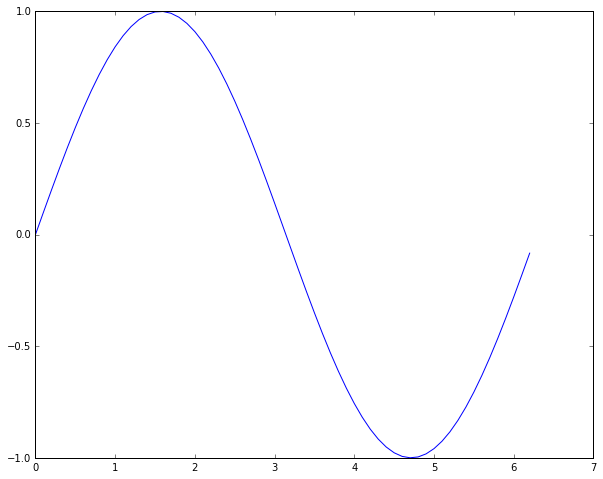

```python
# Importing the libraries
import matplotlib.pyplot as plt
import numpy as np
plt.rcParams["figure.figsize"] = (10, 8)

# Creating the x-axis array (from 0 to 2pi, step of 0.1)
x = np.arange(0, 2*np.pi, 0.1)

# Creating the y-axis array
y = np.sin(x)

# Making the Plot
plt.plot(x, y)
plt.show()
```

The `plt.plot()` function needs at least one or two argumenst (one if it is a 2d-array). The first argument is the x-axis and the second is the y-axis.

## Adding more plots to the same figure

If we want to plot more data on the same figure, we just need to add more `plt.plot()` functions!

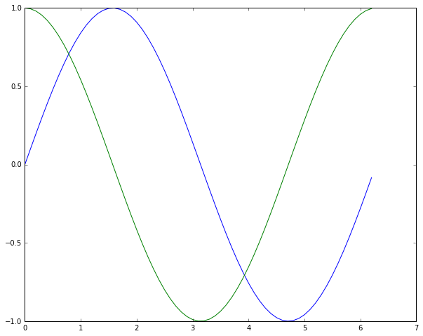

```python
sin = y
cos = np.cos(x)

plt.plot(x, sin)
plt.plot(x, cos)
plt.show()
```

### Add a legend

To add a legend we need to define a label to each `plt.plot` function and add the line `plt.legend()` on the code:

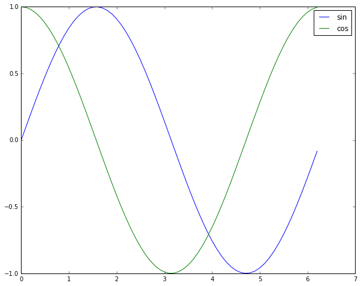

```python
plt.plot(x, sin, label='sin')
plt.plot(x, cos, label='cos')
plt.legend()
plt.show()
```

Usually the legend appears on the upper right position. We can force a better position by using `plt.legend(loc='best')`.

Another options for `loc` are:

```
center left
center right
right
lower right
upper left
best
center
upper center
upper right
lower left
lower center
```

manual positioning and more options at the matplotlib legend [guide](https://matplotlib.org/users/legend_guide.html).

# Customizing

We can customize almost everything on the plot. We can add titles, axis names, change axis limits, background color, line style and markers, line color, grid, etc..

## Adding a title and axis labels

The title is set using the `plt.title('string')` function and the axis labels by using:

- `plt.xlabel('string')` for the x-axis
- `plt.ylabel('string')` for the y-axis

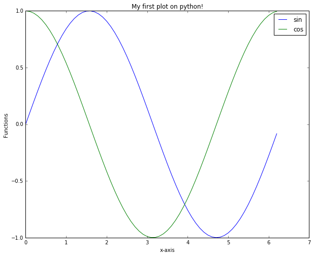

```python
plt.plot(x, sin, label='sin')
plt.plot(x, cos, label='cos')
plt.legend(loc='best')
plt.title('My first plot on python!')
plt.ylabel('Functions')
plt.xlabel('x-axis')
plt.show()
```

### Fontsize

To adjust the fontsize, just add the `fontsize=` option inside the title and label function:

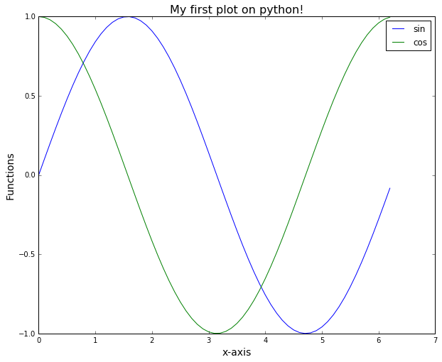

```python
plt.plot(x, sin, label='sin')
plt.plot(x, cos, label='cos')
plt.legend(loc='best')
plt.title('My first plot on python!', fontsize=16)
plt.ylabel('Functions', fontsize=14)
plt.xlabel('x-axis', fontsize=14)
plt.show()
```

## Changing the line style

Matplotlib defines automatically join each point of the plot with a line. We can change the line, add markers or change the linewidth if we want!

| character | description |
| --- | --- |
| '-' | solid line style |
| '--' | dashed line style |
| '-.' | dash-dot line style |
| ':' | dotted line style |
| '.' | point marker |
| ',' | pixel marker |
| 'o' | circle marker |
| 'v' | triangle_down marker |
| '^' | triangle_up marker |
| '<' | triangle_left marker |
| '>' | triangle_right marker |
| '1' | tri_down marker |
| '2' | tri_up marker |
| '3' | tri_left marker |
| '4' | tri_right marker |
| 's' | square marker |
| 'p' | pentagon marker |
| '*' | star marker |
| 'h' | hexagon1 marker |
| 'H' | hexagon2 marker |
| '+' | plus marker |
| 'x' | x marker |
| 'D' | diamond marker |
| 'd' | thin_diamond marker |

The linewidth can be set with the `linewidht=` or `lw=` option inside the plot function.

Example:

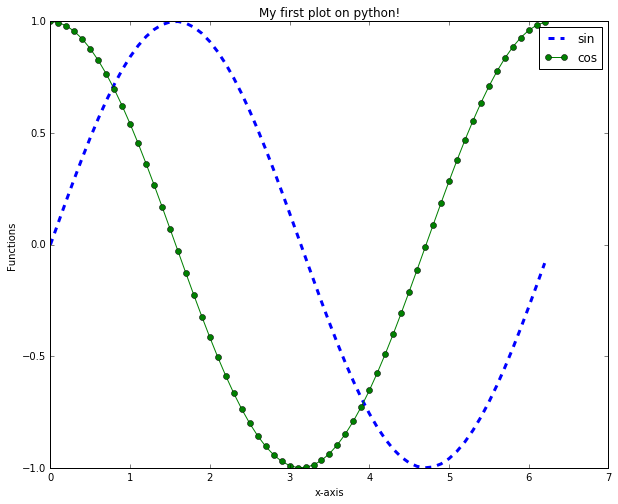

```python
plt.plot(x, sin, '--', lw=3, label='sin')
plt.plot(x, cos, 'o-', lw=1, label='cos') # We can mix a marker with a line! :)
plt.legend(loc='best')
plt.title('My first plot on python!')
plt.ylabel('Functions')
plt.xlabel('x-axis')
plt.show()
```

## But my advisor is colorblind...

Matplotlib automatically defines the colors for the lines and markers. We can set the colors in the same option for the line style and marker.

| character | color |
| --- | --- |
| ‘b’ | blue |
| ‘g’ | green |
| ‘r’ | red |
| ‘c’ | cyan |
| ‘m’ | magenta |
| ‘y’ | yellow |
| ‘k’ | black |
| ‘w’ | white |

A list of all available colors can be seen [here](https://matplotlib.org/examples/color/named_colors.html).

example:

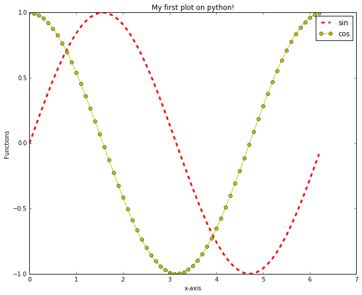

```python
plt.plot(x, sin, 'r--', lw=3, label='sin')
plt.plot(x, cos, 'yo-', lw=1, label='cos')
plt.legend(loc='best')
plt.title('My first plot on python!')
plt.ylabel('Functions')
plt.xlabel('x-axis')
plt.show()
```

## Changing axis limits

Sometimes the lines we plot does not fit on the same axis range. Consider the following example:

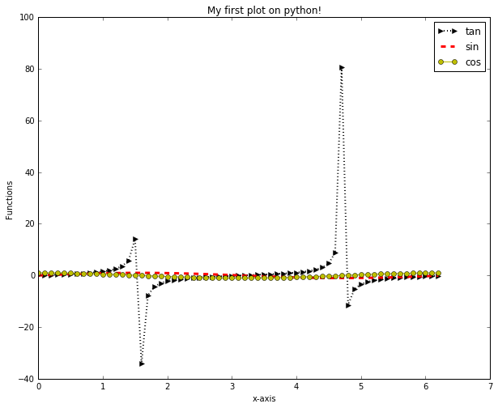

```python
tan = np.tan(x)

plt.plot(x, tan, 'k>:', lw=2, label='tan')
plt.plot(x, sin, 'r--', lw=3, label='sin')
plt.plot(x, cos, 'yo-', lw=1, label='cos')
plt.legend(loc='best')
plt.title('My first plot on python!')
plt.ylabel('Functions')
plt.xlabel('x-axis')
plt.show()
```

The tan function mix up our axis range. We can define the range with the functions:

- `plt.ylim(min, max)` for y-axis
- `plt.xlim(min, max)` for x-axis

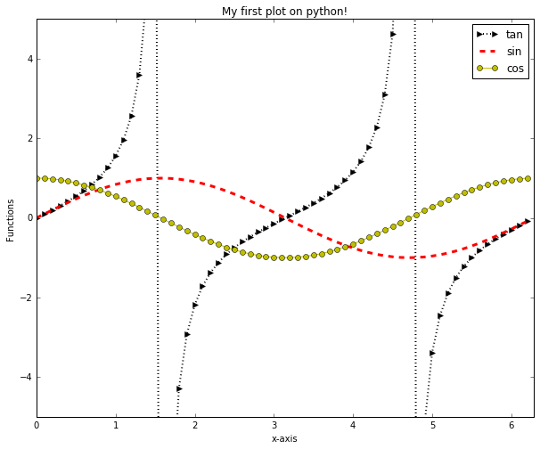

```python
plt.plot(x, tan, 'k>:', lw=2, label='tan')
plt.plot(x, sin, 'r--', lw=3, label='sin')
plt.plot(x, cos, 'yo-', lw=1, label='cos')
plt.legend(loc='best')
plt.title('My first plot on python!')
plt.ylabel('Functions')
plt.xlabel('x-axis')
plt.xlim(0, 2*np.pi)
plt.ylim(-5, 5)
plt.show()
```

### Can I use $\LaTeX$ math on labels?

YES! Matplotlib supports $\LaTeX$ math mode on legend, axis labels, etc.. But you need to have LaTeX installed on your system.

To use the $\LaTeX$ sintax we have to use: `r'$string$'`

Example:

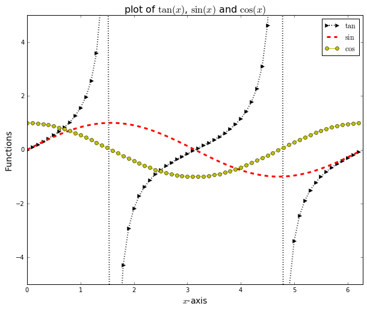

```python
plt.plot(x, tan, 'k>:', lw=2, label=r'$\tan$')
plt.plot(x, sin, 'r--', lw=3, label=r'$\sin$')
plt.plot(x, cos, 'yo-', lw=1, label=r'$\cos$')
plt.legend(loc='best')
plt.title(r"plot of $\tan (x)$, $\sin(x)$ and $\cos(x)$", fontsize=16)
plt.ylabel('Functions', fontsize=14)
plt.xlabel(r'$x$-axis', fontsize=14)
plt.xlim(0, 2*np.pi)
plt.ylim(-5, 5)
plt.show()
```

### Adding a grid

Just add `plt.grid()` to the script!

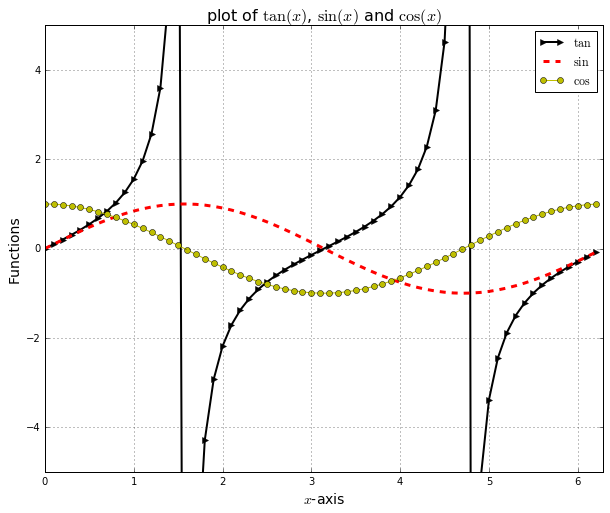

```python
plt.plot(x, tan, 'k>-', lw=2, label=r'$\tan$')
plt.plot(x, sin, 'r--', lw=3, label=r'$\sin$')
plt.plot(x, cos, 'yo-', lw=1, label=r'$\cos$')
plt.legend(loc='best')
plt.title(r"plot of $\tan (x)$, $\sin(x)$ and $\cos(x)$", fontsize=16)
plt.ylabel('Functions', fontsize=14)
plt.xlabel(r'$x$-axis', fontsize=14)
plt.xlim(0, 2*np.pi)
plt.ylim(-5, 5)
plt.grid()
plt.show()
```

### Changing axis numbers

We can define the what are going to be plotted on the axis of our plot using the functions:

- `plt.xticks([position], [value or symbol])` for x-axis
- `plt.yticks([position], [value or symbol])` for y-axis

For example, I want to change the numbers on the x-axis by multiples of $\pi$. I can do this by defining the new values and the position they will occupy:

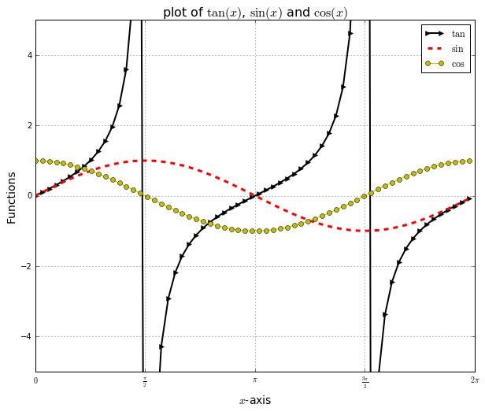

```python
position = [0, np.pi/2, np.pi, 3*np.pi/2, 2*np.pi]
values = [r'$0$', r'$\frac{\pi}{2}$', r'$\pi$', r'$\frac{3\pi}{2}$', r'$2\pi$']

plt.plot(x, tan, 'k>-', lw=2, label=r'$\tan$')
plt.plot(x, sin, 'r--', lw=3, label=r'$\sin$')
plt.plot(x, cos, 'yo-', lw=1, label=r'$\cos$')
plt.legend(loc='best')
plt.title(r"plot of $\tan (x)$, $\sin(x)$ and $\cos(x)$", fontsize=16)
plt.ylabel('Functions', fontsize=14)
plt.xlabel(r'$x$-axis', fontsize=14)
plt.xlim(0, 2*np.pi)
plt.ylim(-5, 5)
plt.grid()
plt.xticks(position, values)
plt.show()
```

# Saving the Plot

The function to save your plot into a file is:

```
plt.savefig('name.extension')
```

To save your figure you need at least one argument, which is a string with the name and extension of your figure. A list of all the supported extensions are below:

```python
import matplotlib as mpl
mpl.rcParams.update(mpl.rcParams)#Default)
plt.gcf().canvas.get_supported_filetypes()
```

```
{'eps': 'Encapsulated Postscript',
 'jpeg': 'Joint Photographic Experts Group',
 'jpg': 'Joint Photographic Experts Group',
 'pdf': 'Portable Document Format',
 'pgf': 'PGF code for LaTeX',
 'png': 'Portable Network Graphics',
 'ps': 'Postscript',
 'raw': 'Raw RGBA bitmap',
 'rgba': 'Raw RGBA bitmap',
 'svg': 'Scalable Vector Graphics',
 'svgz': 'Scalable Vector Graphics',
 'tif': 'Tagged Image File Format',
 'tiff': 'Tagged Image File Format'}
```

One nice option for the `plt.savefig()` function is the `dpi=` argument (dots per inches). If you want to create a figure large enough for a poster you can set `dpi=300` (or just use the .pdf or .ps format!)

More information on the [documentation of savefig function](https://matplotlib.org/devdocs/api/_as_gen/matplotlib.pyplot.savefig.html)

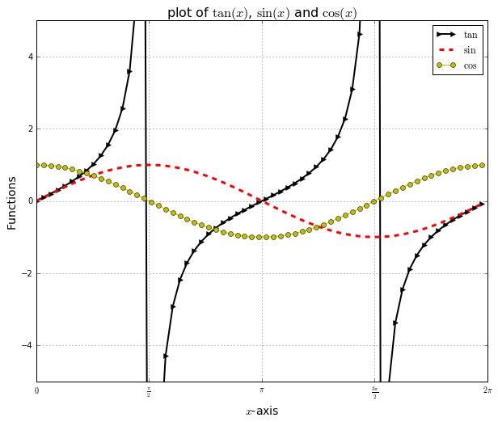

```python
plt.plot(x, tan, 'k>-', lw=2, label=r'$\tan$')
plt.plot(x, sin, 'r--', lw=3, label=r'$\sin$')
plt.plot(x, cos, 'yo-', lw=1, label=r'$\cos$')
plt.legend()
plt.title(r"plot of $\tan (x)$, $\sin(x)$ and $\cos(x)$", fontsize=16)
plt.ylabel('Functions', fontsize=14)
plt.xlabel(r'$x$-axis', fontsize=14)
plt.xlim(0, 2*np.pi)
plt.ylim(-5, 5)
plt.grid()
plt.xticks(position, values)
#plt.show()
plt.savefig('plot.pdf')            # pdf format
plt.savefig('plot.png')            # png format with low resolution
plt.savefig('plot2.png', dpi=300)  # png format with high resolution
```

# A "formal" approach to the plot function

The `plt.plot` function is kind of "lazy" because it let you join the colors, marker, and linestyle together in one string. For a more formal approach, you need to set those arguments separated from each other. This is usefull because all the others plotting routines does not allow to join the arguments.

So, the "formal" plot function should be like this:

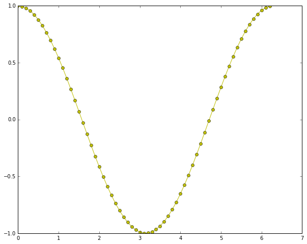

```python
plt.plot(x, cos, marker='o', color='y', linestyle='-', lw=1, label=r'$\cos$')
```

# Subplots

You can create an image with many plots as you desire. For this taks, matplotlib has the `plt.subplot()` function!

*the subplot function needs to be called before the plot function, because the subplot only defines the matrix and position of the plots. The subplot function does not plot!*

```
plt.subplot(nrows, ncols, plot_number, ...)
```

you need at least 3 arguments to create subplots: number of rows, number of columns and the plot number.

Example:

Lets create an image with 3 plots, on upon each other:

## Vertical plots

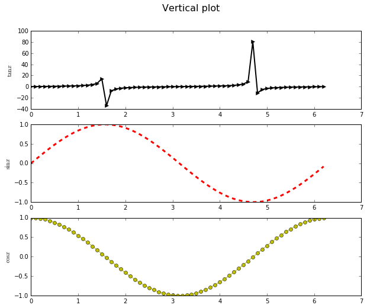

```python
plt.subplot(3, 1, 1) # 3 lines, 1 column, plot number 1
plt.plot(x, tan, 'k>-', lw=2, label=r'$\tan$')
plt.ylabel(r'$\tan x$')

plt.subplot(3, 1, 2) # 3 lines, 1 column, plot number 2
plt.plot(x, sin, 'r--', lw=3, label=r'$\sin$')
plt.ylabel(r'$\sin x$')

plt.subplot(3, 1, 3) # 3 lines, 1 column, plot number 3
plt.plot(x, cos, 'yo-', lw=1, label=r'$\cos$')
plt.ylabel(r'$\cos x$')

plt.suptitle('Vertical plot', fontsize=16)
```

## Horizontal Plot

Now lets make plots side by side:

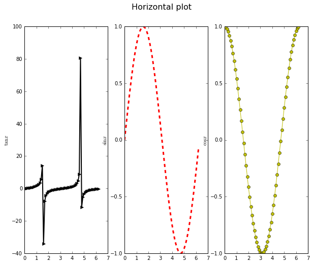

```python
plt.subplot(1, 3, 1) # 1 lines, 3 column, plot number 1
plt.plot(x, tan, 'k>-', lw=2, label=r'$\tan$')
plt.ylabel(r'$\tan x$')

plt.subplot(1, 3, 2) # 1 lines, 3 column, plot number 2
plt.plot(x, sin, 'r--', lw=3, label=r'$\sin$')
plt.ylabel(r'$\sin x$')

plt.subplot(1, 3, 3) # 1 lines, 3 column, plot number 3
plt.plot(x, cos, 'yo-', lw=1, label=r'$\cos$')
plt.ylabel(r'$\cos x$')

plt.suptitle('Horizontal plot', fontsize=16)
```

## Grid Plot

Now a grid plot:

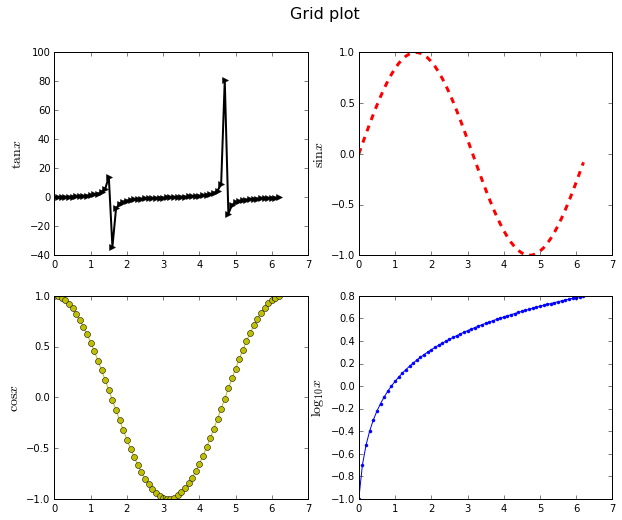

```python
plt.subplot(2, 2, 1) # 2 lines, 2 column, plot number 1
plt.plot(x, tan, 'k>-', lw=2, label=r'$\tan$')
plt.ylabel(r'$\tan x$', fontsize=14)

plt.subplot(2, 2, 2) # 2 lines, 2 column, plot number 2
plt.plot(x, sin, 'r--', lw=3, label=r'$\sin$')
plt.ylabel(r'$\sin x$', fontsize=14)

plt.subplot(2, 2, 3) # 2 lines, 2 column, plot number 3
plt.plot(x, cos, 'yo-', lw=1, label=r'$\cos$')
plt.ylabel(r'$\cos x$', fontsize=14)

plt.subplot(2, 2, 4) # 2 lines, 2 column, plot number 4
plt.plot(x, np.log10(x+0.1), 'b.-', lw=1, label=r'$\cos$')
plt.ylabel(r'$\log_{10} x$', fontsize=14)

plt.suptitle('Grid plot', fontsize=16)
```

# There is more customization?

Yes! You can customize almost everything! You can take a look at the [Customizing guide](http://matplotlib.org/users/customizing.html) to see all the options. Or, you can use one of the pre-sets styles:

[output not shown]

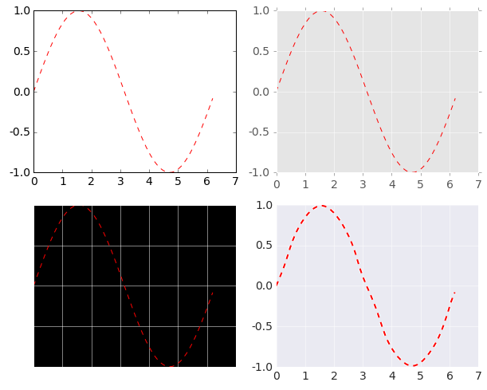

```python
print(plt.style.available)

plt.subplot(221)
plt.style.use('ggplot')
plt.plot(x, sin, 'r--')

plt.subplot(222)
plt.style.use('dark_background')
plt.plot(x, sin, 'r--')

plt.subplot(223)
plt.style.use('seaborn-darkgrid')
plt.plot(x, sin, 'r--')

plt.subplot(224)
plt.xkcd()
plt.plot(x, sin, 'r--')
```